# Assignment_03_Dataset_01_Solution

```python
import pandas as pd
import numpy as np
from sklearn.model_selection import train_test_split
from sklearn.preprocessing import PolynomialFeatures
import matplotlib.pyplot as plt
import seaborn as sns

# Step 1: Load the dataset
file_path = 'Group03/Regression/UnivariateData/3.csv'
data = pd.read_csv(file_path)

# Assuming the dataset has one column of input data and one column of output data
X = data.iloc[:, 0].values  # Input (independent variable)
y = data.iloc[:, 1].values  # Output (dependent variable)

# Split the dataset into training and testing sets (70% training, 30% testing)
X_train, X_test, y_train, y_test = train_test_split(X, y, test_size=0.3, random_state=42)

# Reshape data for polynomial fitting
X_train = X_train[:, np.newaxis]
X_test = X_test[:, np.newaxis]

# Step 2: Save the training and testing data to new files
train_data = pd.DataFrame({'X_train': X_train.flatten(), 'y_train': y_train})
test_data = pd.DataFrame({'X_test': X_test.flatten(), 'y_test': y_test})

train_data.to_csv('Group03/Regression/UnivariateData/train_data.csv', index=False)
test_data.to_csv('Group03/Regression/UnivariateData/test_data.csv', index=False)

# Step 3: Read the files back for EDA
train_data = pd.read_csv('Group03/Regression/UnivariateData/train_data.csv')
test_data = pd.read_csv('Group03/Regression/UnivariateData/test_data.csv')
```

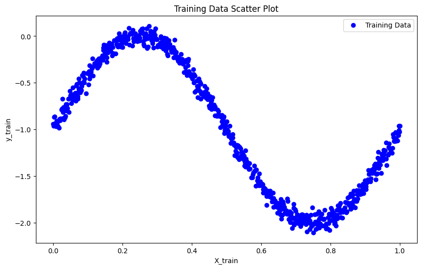

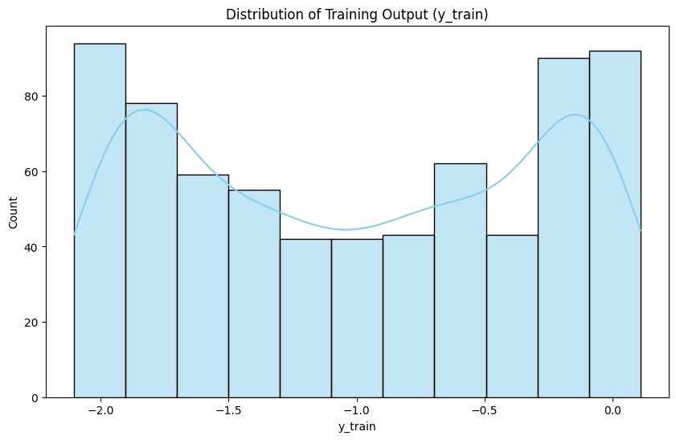

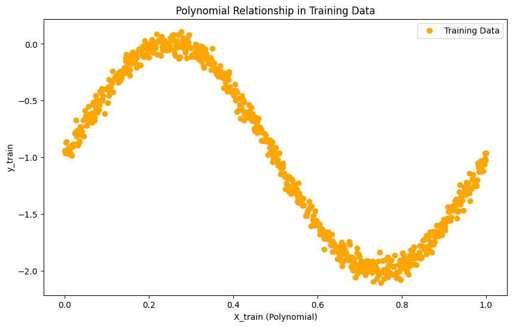

```python
# Step 4: Perform EDA for Univariate Polynomial Regression

# Visualize the training data
plt.figure(figsize=(10, 6))
plt.scatter(train_data['X_train'], train_data['y_train'], color='blue', label='Training Data')
plt.xlabel('X_train')
plt.ylabel('y_train')
plt.title('Training Data Scatter Plot')
plt.legend()
plt.show()

# Distribution plot of training output
plt.figure(figsize=(10, 6))
sns.histplot(train_data['y_train'], kde=True, color='skyblue')
plt.xlabel('y_train')
plt.title('Distribution of Training Output (y_train)')
plt.show()

# Polynomial transformation of degree 2 for visualization
poly = PolynomialFeatures(degree=2)
X_poly_train = poly.fit_transform(train_data[['X_train']])

# Scatter plot for polynomial relationship
plt.figure(figsize=(10, 6))
plt.scatter(X_poly_train[:, 1], train_data['y_train'], color='orange', label='Training Data')
plt.xlabel('X_train (Polynomial)')
plt.ylabel('y_train')
plt.title('Polynomial Relationship in Training Data')
plt.legend()
plt.show()
```

### 1. Training Data Scatter Plot

- **What It Represents**: The scatter plot displays the relationship between the independent variable ( X_{\text{train}} ) and the dependent variable ( y_{\text{train}} ) in the training dataset.
- **How It Helps**: This initial visualization gives a clear view of the data distribution and any apparent relationship between ( X ) and ( y ). For polynomial regression, we're interested in seeing if the data might follow a curved pattern rather than a straight line, which would suggest a non-linear relationship.

### 2. Distribution of Training Output (Histogram with KDE)

- **What It Represents**: This histogram, with a Kernel Density Estimation (KDE) overlay, shows the distribution of ( y_{\text{train}} ) values in the training dataset.
- **How It Helps**: Understanding the output variable's distribution helps detect skewness or unusual spread, indicating possible outliers or non-normality. For polynomial regression, knowing the target's distribution helps to adjust model assumptions or preprocessing techniques if needed.

### Overall Importance for Univariate Polynomial Regression

These visualizations help to:

- **Detect Non-Linearity**: Assess if a linear model is insufficient and if polynomial regression is likely to capture data trends better.
- **Identify Data Patterns**: See if there’s a consistent pattern, e.g., quadratic or cubic, that suggests the best polynomial degree.
- **Prepare for Preprocessing**: Check for outliers, skewness, or unusual data points, which may require transformations or cleaning to improve model performance.

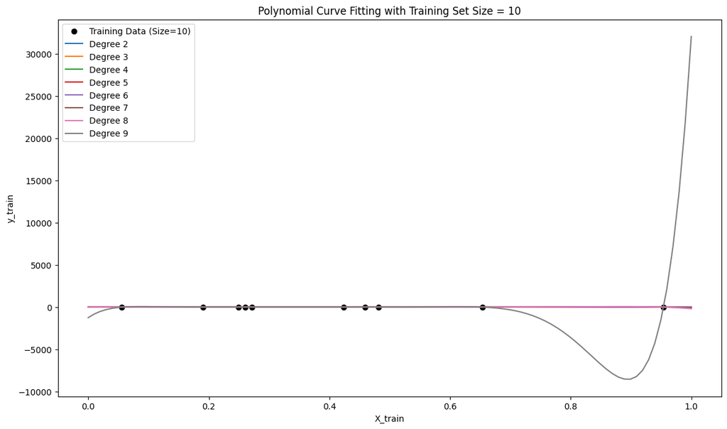

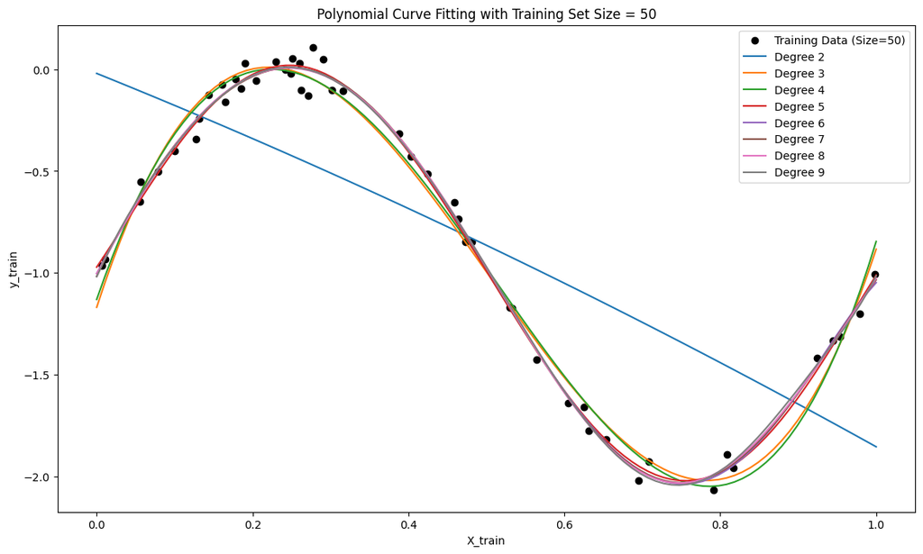

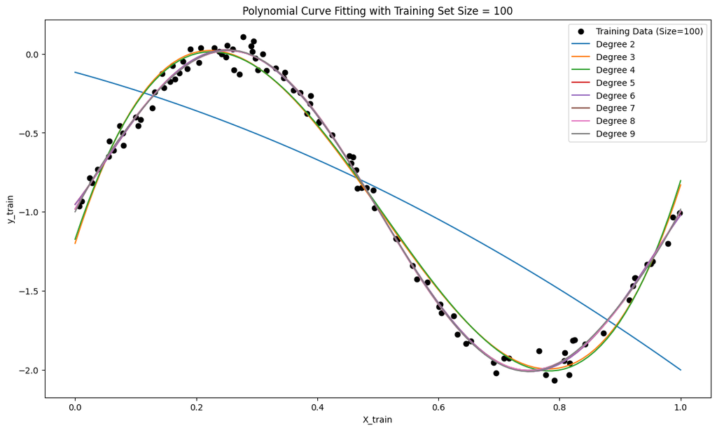

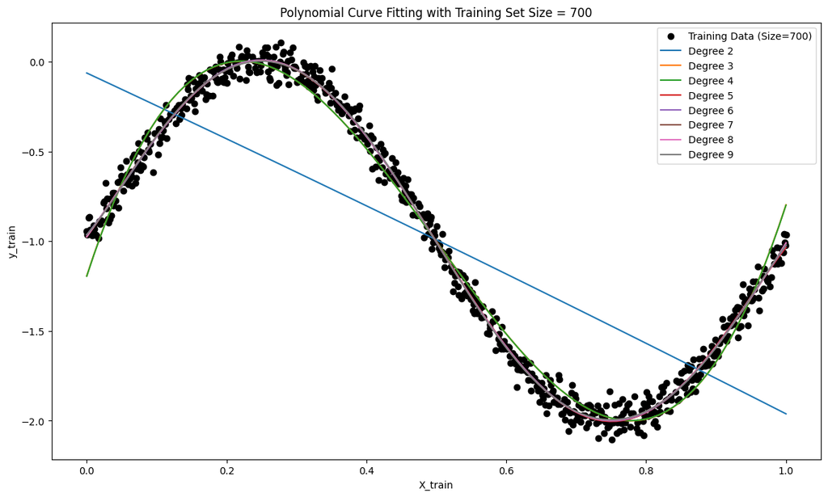

```python
import pandas as pd
import numpy as np
from sklearn.preprocessing import PolynomialFeatures
from sklearn.linear_model import LinearRegression
import matplotlib.pyplot as plt

# Step 1: Load the dataset
train_data = pd.read_csv('Group03/Regression/UnivariateData/train_data.csv')
test_data = pd.read_csv('Group03/Regression/UnivariateData/test_data.csv')

# Separate features and targets
X_train_full = train_data['X_train'].values.reshape(-1, 1)
y_train_full = train_data['y_train'].values

# Define training subset sizes
subset_sizes = [10, 50, 100, len(X_train_full)]

# Define polynomial degrees to test
degrees = range(2, 10)

# Loop through each subset size
for size in subset_sizes:
    # Sample the training data to create a subset
    X_train_subset = X_train_full[:size]
    y_train_subset = y_train_full[:size]

    plt.figure(figsize=(14, 8))
    plt.scatter(X_train_subset, y_train_subset, color='black', label=f'Training Data (Size={size})')

    # Loop through polynomial degrees
    for degree in degrees:
        # Create a polynomial feature transformer for the given degree
        poly = PolynomialFeatures(degree=degree)

        # Transform X data to polynomial features
        X_train_poly = poly.fit_transform(X_train_subset)

        # Train a Linear Regression model on the polynomial-transformed data
        model = LinearRegression()
        model.fit(X_train_poly, y_train_subset)

        # Generate predictions across the full range of X values for smooth plotting
        X_range = np.linspace(X_train_full.min(), X_train_full.max(), 100).reshape(-1, 1)
        X_range_poly = poly.transform(X_range)
        y_pred = model.predict(X_range_poly)

        # Plot the polynomial fit line for this degree
        plt.plot(X_range, y_pred, label=f'Degree {degree}')

    plt.title(f'Polynomial Curve Fitting with Training Set Size = {size}')
    plt.xlabel('X_train')
    plt.ylabel('y_train')
    plt.legend()
    plt.show()
```